# Combining shapefile with dataset

## Juan Andrés Cabral

### Description of the Script

This Python script processes and visualizes greenhouse gas emission data from Argentina for the years 2010 to 2018. Dataset can be downloaded Here. Shapefile and associated files can be downloaded [Here](https://github.com/cabraljuan/cabraljuan.github.io/raw/main/tutorials/datasets/shapefiles_arg.rar).

#### 1. **Data Loading**

The script begins by specifying a path to the data directory and then loads an Excel file containing the emissions data. This dataset, named `df`, captures the emissions for different jurisdictions (provinces) within Argentina.

#### 2. **Data Cleaning**

After loading the data:

- The script removes empty rows and columns.
- Renames columns for clarity.
- Ensures the data types are appropriate for further analysis. Specifically, the jurisdiction names are converted to strings, and the yearly emission figures are converted to floats.

#### 3. **Data Transformation**

It calculates the change in emissions from 2010 to 2018 for each jurisdiction and appends this as a new column (`change`) to the dataset.

#### 4. **Geospatial Data Integration**

The code then:

- Incorporates geospatial data (from a shapefile) representing the boundaries of the provinces in Argentina.
- Merges this geospatial data with the emissions data using the province/jurisdiction names.

#### 5. **Visualization**

Finally, the script:

- Creates a high-resolution map visualizing the boundaries of each province.
- Colors them based on the calculated change in emissions from 2010 to 2018.
- The map is centered on Argentina, and axis labels are removed for clarity.
- The resulting visualization can optionally be saved as an image file.

```python
import pandas as pd
import matplotlib.pyplot as plt
import geopandas as gpd

# Path
path = "E:/articulos/argentina-ghg/"

# Load the first sheet "Total Pais" from the Excel file
file_path = path + 'input/desagregacion-provincial_(2010_2018).xlsx'
sheet_name = 'Total Pais'

# Read a few rows to get an overview of the data
df = pd.read_excel(file_path, sheet_name=sheet_name, skiprows=5)

# Drop any completely empty rows or columns
df.dropna(how='all', inplace=True)
df.dropna(axis=1, how='all', inplace=True)

# Step 2: Rename columns
# Rename the first column to 'Jurisdiction' and the rest to their respective years
correct_columns = ['Jurisdiction'] + [str(year) for year in range(2010, 2019)]
df.columns = correct_columns

# Step 3: Convert data types
# Convert the 'Jurisdiction' column to string and year columns to float
df['Jurisdiction'] = df['Jurisdiction'].astype(str)
for year in correct_columns[1:]:
    df[year] = df[year].astype(float)

# Display cleaned dataframe (optional)
print(df.head())
```

```
                      Jurisdiction        2010        2011        2012  \
0                       Total Pais  373.477735  371.189923  407.659166
2                      Sin asignar   40.405523   41.249071   39.896586
3  Ciudad Autónoma de Buenos Aires   18.551483   20.727705   20.313776
4                     Buenos Aires   84.795547   82.286993   89.218730
5                        Catamarca    1.412102    1.888391    2.028079

         2013        2014        2015        2016        2017        2018
0  411.030979  384.023971  366.396267  359.673052  370.159724  365.889794
2   44.164627   44.641829   44.239261   43.834199   45.294989   47.272842
3   19.204610   18.006212   18.694618   18.428503   17.602730   15.693272
4   93.004934   92.249117   89.281197   94.374863   85.761024   93.792030
5    2.241525    1.242369    1.064319    1.494383    1.970846    0.835929
```

```python
# Rename the row where 'Jurisdiction' is 'Tierra del Fuego, Antarctica and South Atlantic Islands' to 'Tierra del Fuego'
df.loc[df['Jurisdiction'] == 'Tierra del Fuego, Antártida e Islas del Atlántico Sur', 'Jurisdiction'] = 'Tierra del Fuego'

# Remove the last 3 rows from the dataframe
df = df.iloc[:-3]

# Display the last few rows of the dataframe to confirm the changes
df.tail()
```

|  | Jurisdiction | 2010 | 2011 | 2012 | 2013 | 2014 | 2015 | 2016 | 2017 | 2018 |
| --- | --- | --- | --- | --- | --- | --- | --- | --- | --- | --- |
| 22 | Santa Cruz | 7.242625 | 6.933753 | 7.256118 | 7.281231 | 7.377757 | 7.466951 | 7.335986 | 7.108920 | 6.974536 |
| 23 | Santa Fe | 24.646441 | 26.944307 | 27.714709 | 29.600614 | 28.644248 | 28.292507 | 28.496881 | 27.193841 | 26.922312 |
| 24 | Santiago del Estero | 27.673284 | 30.616677 | 30.298089 | 31.288838 | 22.321433 | 18.719216 | 16.297966 | 20.135978 | 16.572504 |
| 25 | Tucumán | 7.101321 | 7.089497 | 7.922411 | 7.606891 | 7.609264 | 7.855399 | 6.977381 | 6.975885 | 6.642570 |
| 26 | Tierra del Fuego | 5.021536 | 4.925542 | 5.029836 | 4.894071 | 3.100110 | 3.061547 | 3.268451 | 3.335445 | 3.143657 |

```python
# Calculate the change from 2010 to 2018 for each row
df['change'] = df['2018'] - df['2010']

# Display the dataframe with the new column
df.head(10)
```

|  | Jurisdiction | 2010 | 2011 | 2012 | 2013 | 2014 | 2015 | 2016 | 2017 | 2018 | change |
| --- | --- | --- | --- | --- | --- | --- | --- | --- | --- | --- | --- |
| 0 | Total Pais | 373.477735 | 371.189923 | 407.659166 | 411.030979 | 384.023971 | 366.396267 | 359.673052 | 370.159724 | 365.889794 | -7.587941 |
| 2 | Sin asignar | 40.405523 | 41.249071 | 39.896586 | 44.164627 | 44.641829 | 44.239261 | 43.834199 | 45.294989 | 47.272842 | 6.867319 |
| 3 | Ciudad Autónoma de Buenos Aires | 18.551483 | 20.727705 | 20.313776 | 19.204610 | 18.006212 | 18.694618 | 18.428503 | 17.602730 | 15.693272 | -2.858211 |
| 4 | Buenos Aires | 84.795547 | 82.286993 | 89.218730 | 93.004934 | 92.249117 | 89.281197 | 94.374863 | 85.761024 | 93.792030 | 8.996484 |
| 5 | Catamarca | 1.412102 | 1.888391 | 2.028079 | 2.241525 | 1.242369 | 1.064319 | 1.494383 | 1.970846 | 0.835929 | -0.576172 |
| 6 | Córdoba | 28.762447 | 26.263621 | 23.353450 | 18.016880 | 24.502811 | 24.991885 | 21.510263 | 23.809129 | 27.710588 | -1.051859 |
| 7 | Corrientes | -1.582357 | -1.789908 | 2.382229 | 2.135111 | 1.783299 | 0.353670 | -0.913049 | 0.562175 | -1.596255 | -0.013897 |
| 8 | Chaco | 23.522462 | 25.630849 | 30.670467 | 31.287196 | 20.651086 | 20.986068 | 19.516270 | 22.734632 | 20.054211 | -3.468251 |
| 9 | Chubut | 9.574052 | 10.259267 | 9.746987 | 9.861211 | 19.037145 | 19.692655 | 19.487096 | 18.921365 | 9.536945 | -0.037107 |
| 10 | Entre Ríos | 14.368488 | 14.142667 | 14.120527 | 14.302901 | 13.036897 | 11.510080 | 10.435675 | 10.459301 | 10.005564 | -4.362924 |

```python
# Combine with shapefile
# Load the GeoJSON or Shapefile
gdf = gpd.read_file(path + "input/provincias.shp")
print(gdf['NAM'])
```

```
0                       Ciudad Autónoma de Buenos Aires
1                                               Neuquén
2                                              La Pampa
3                                               Mendoza
4                                              San Luis
5                                               Córdoba
6                                              Santa Fe
7                                            Entre Ríos
8                                              San Juan
9                                              La Rioja
10                                            Catamarca
11                                              Tucumán
12                                                Jujuy
13                                                Chaco
14                                              Formosa
15                                  Santiago del Estero
16    Tierra del Fuego, Antártida e Islas del Atlánt...
17                                           Santa Cruz
18                                               Chubut
19                                            Río Negro
20                                         Buenos Aires
21                                           Corrientes
22                                             Misiones
23                                                Salta
Name: NAM, dtype: object
```

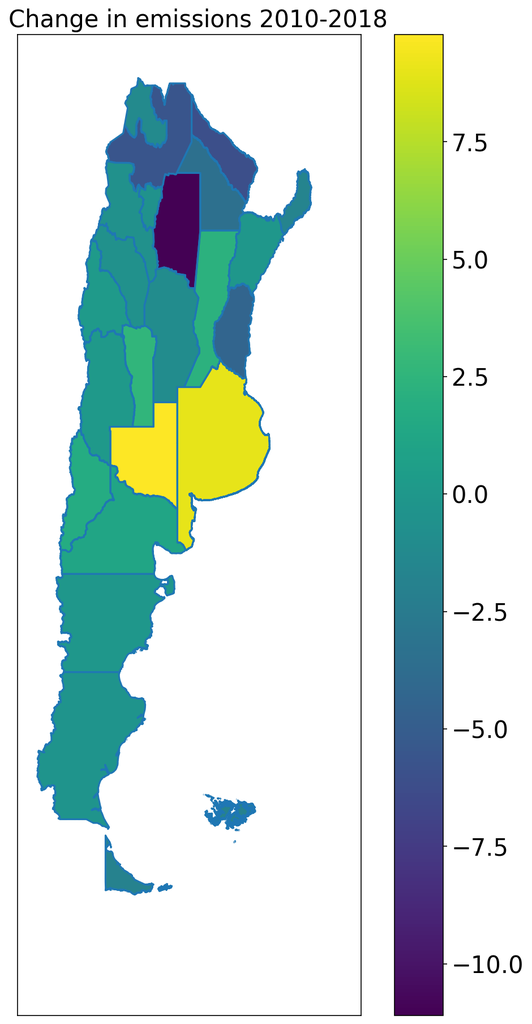

```python
# Change name to match with another dataset
gdf.loc[gdf['NAM'] == 'Tierra del Fuego, Antártida e Islas del Atlántico Sur', 'NAM'] = 'Tierra del Fuego'

# Get unique values in both columns
unique_nam = set(gdf['NAM'].unique())
unique_province = set(df['Jurisdiction'].unique())

# Find names present in 'NAM' but not in 'Province'
in_nam_not_in_province = unique_nam - unique_province

# Find names present in 'Province' but not in 'NAM'
in_province_not_in_nam = unique_province - unique_nam

merged = gdf.merge(df, left_on="NAM", right_on="Jurisdiction", how="left")

# Create a high-resolution figure
fig, ax = plt.subplots(1, figsize=(10, 15), dpi=150)

# Draw the geometries of the provinces and color them according to the 'Total Hectares' column
merged.boundary.plot(ax=ax)
merged.plot(column='change', ax=ax, legend=True, legend_kwds={'label': ""})

# Set x and y axis limits to center the map on the region of interest
ax.set_xlim([-75, -50])  # Adjust these values as needed
ax.set_ylim([-60, -20])  # Adjust these values as needed

# Remove the axis labels
ax.set_xticks([])
ax.set_yticks([])

fig = ax.figure

cb_ax = fig.axes[1]
cb_ax.tick_params(labelsize=20)
title = cb_ax.set_title("Change in emissions 2010-2018", fontsize=20, loc='center')
title.set_position((-4, 1.0))  # (x, y)

# Uncomment to save the image
# plt.savefig(path + "/output/graphs/gei_evolution_provinces_map.png")

plt.show()
```